# Лабораторная работа № 13

Настройка NFS

Жукова С. В. НПИбд-01-24

Российский университет дружбы народов, Москва, Россия

28 ноября 2026

## Докладчик

- Жукова София Викторовна
- студентка
- направления прикладной информатика
- Российский университет дружбы народов
- 1032240966@pfur.ru
- https://svzhukova.github.io/ru/

# Вводная часть

Настройка NFS

## Цель работы

Приобретение навыков настройки сервера NFS для удалённого доступа к ресурсам.

## Выполнение лабораторной работы

**Настройка сервера NFSv4**

На сервере установим необходимое программное обеспечение и создадим каталог, который предполагается сделать доступным всем пользователям сети (корень дерева NFS)

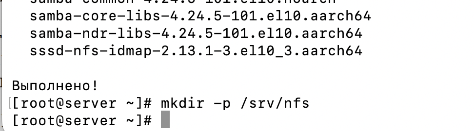

Создаем каталог

## В файле /etc/exports пропишем подключаемый через NFS общий каталог с доступом только на чтение

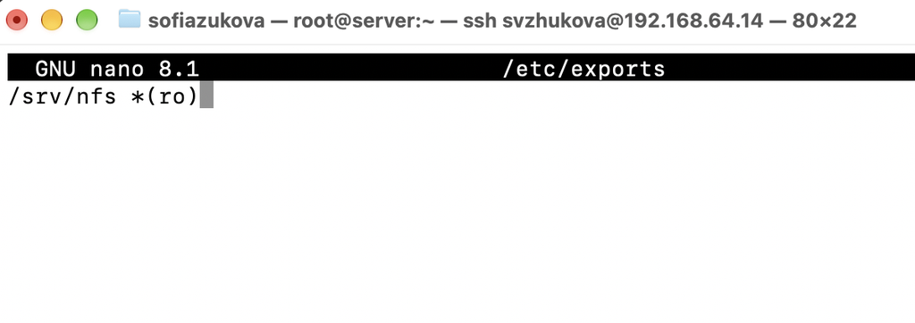

Скрипт

## Для общего каталога зададим контекст безопасности NFS. Применим изменённую настройку SELinux к файловой системе. Запустим сервер NFS и Настроим межсетевой экран для работы сервера NFS

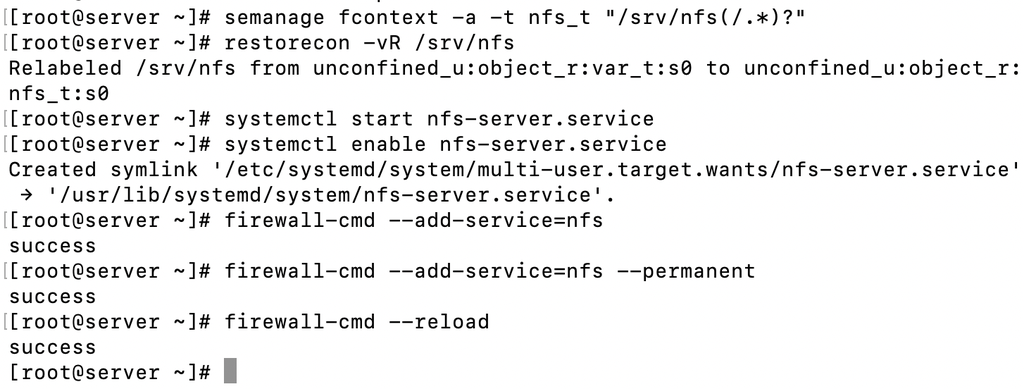

Выполнение

## На клиенте попробуем посмотреть имеющиеся подмонтированные удалённые ресурсы

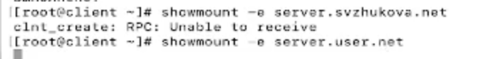

Oтказано

Команда showmount -e server.svzhukova.net запрашивает у сервера список экспортируемых каталогов. Для этого она обращается не к NFSv4 (порт 2049), а к службам rpcbind (порт 111) и mountd. Межсетевой экран сервера пропускает только службу nfs, то есть порт 2049, поэтому запросы к rpcbind блокируются, и клиент получает ошибку clnt_create: RPC: Unable to receive.

## На сервере посмотрим, какие службы задействованы при удалённом монтировании

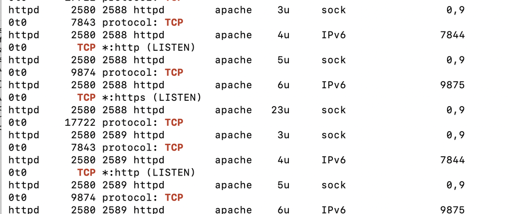

TCP

## UDP

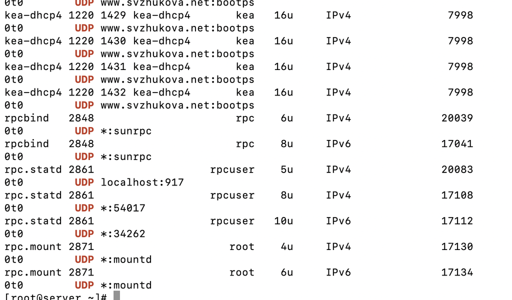

UDP

## Добавим службы rpc-bind и mountd в настройки межсетевого экрана на сервере

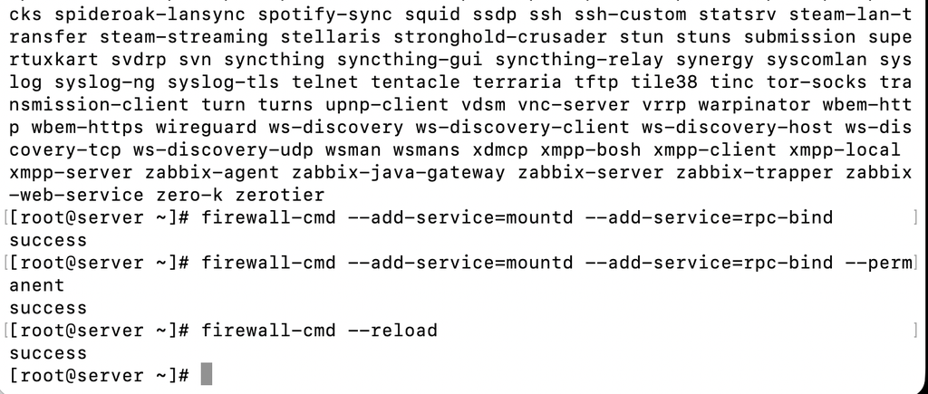

Добавляем

## На клиенте проверим подключение удалённого ресурса

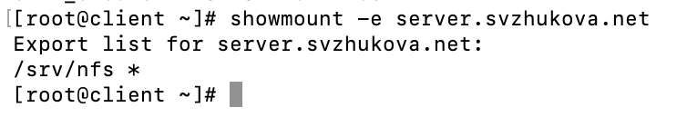

Подключен

## Монтирование NFS на клиенте

На клиенте создадим каталог, в который будет монтироваться удалённый ресурс, и подмонтируем дерево NFS, проверим, что общий ресурс NFS подключён правильно

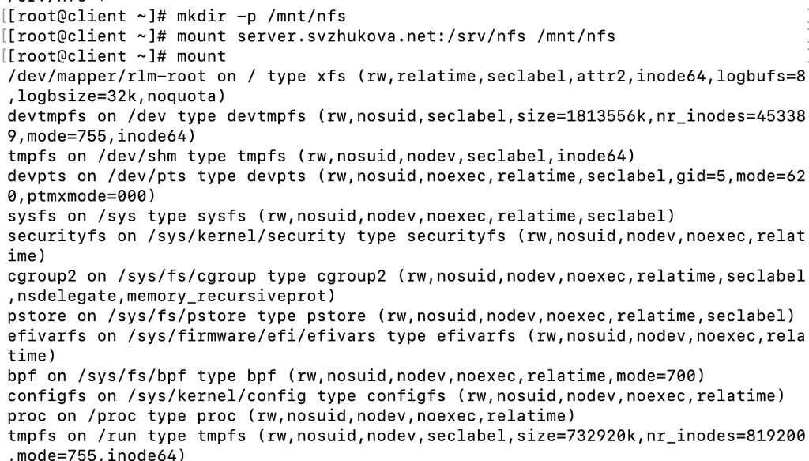

Подключен

## На клиенте в конце файла /etc/fstab добавим следующую запись

[figure not shown]

Запись

## На клиенте проверим наличие автоматического монтирования удалённых ресурсов при запуске операционной системы

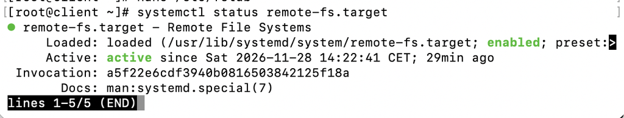

Активно

## Перезапустим клиента и убедимся, что удалённый ресурс подключается автоматически

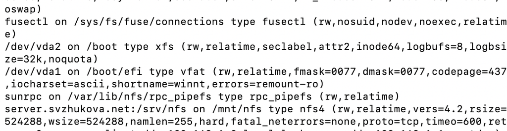

Подключается

## Подключение каталогов к дереву NFS

На сервере создадим общий каталог, в который затем будет подмонтирован каталог с контентом веб-сервера, подмонтируем каталог web-сервера. На сервере проверим, что отображается в каталоге /srv/nfs

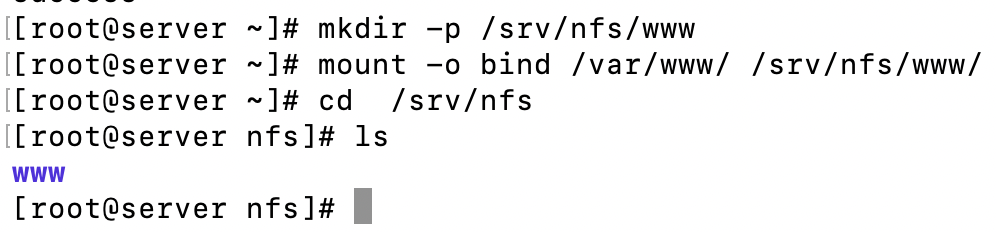

www

## На сервере в файле /etc/exports добавим экспорт каталога веб-сервера с удалённого ресурса и экспортируйте все каталоги, упомянутые в файле /etc/exports

[figure not shown]

скрипт

## На сервере в конце файла /etc/fstab добавим следующую запись и повторно экспортируем каталоги, указанные в файле /etc/exports

[figure not shown]

Файл

## На клиенте проверим каталог /mnt/nfs

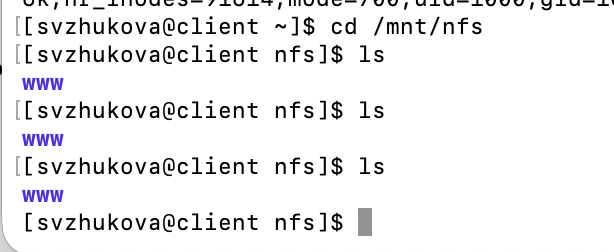

www

## Подключение каталогов для работы пользователей

На сервере под пользователем user в его домашнем каталоге создадим каталог common с полными правами доступа только для этого пользователя, а в нём файл user@server.txt

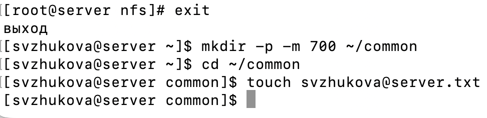

создаем

## Подключим каталог пользователя в файле /etc/exports, прописав в нём

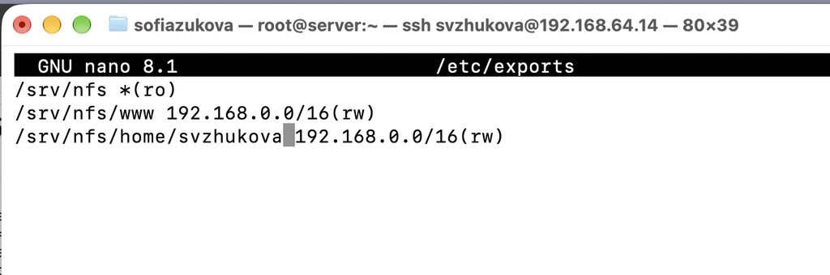

Подключим

## Внесем изменения в файл /etc/fstab

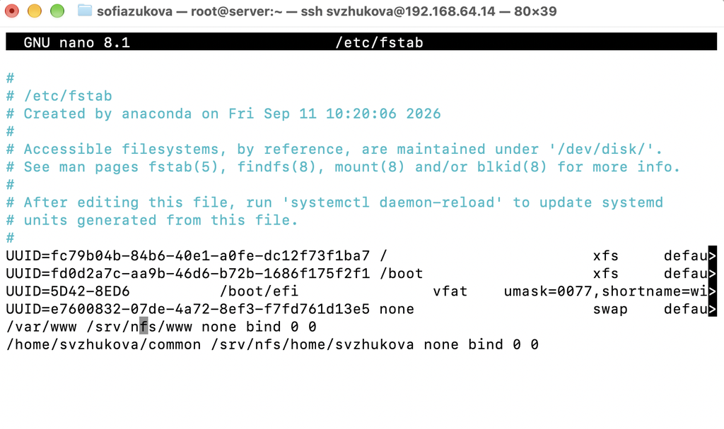

изменения

## На клиенте проверим каталог /mnt/nfs

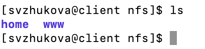

проверим

## Внесение изменений в настройки внутреннего окружения виртуальных машин

На виртуальной машине server перейдем в каталог для внесения изменений в настройки внутреннего окружения /vagrant/provision/server/, создадим в нём каталог nfs, в который поместим в соответствующие подкаталоги конфигурационные файлы, в каталоге /vagrant/provision/server создадим исполняемый файл nfs.sh

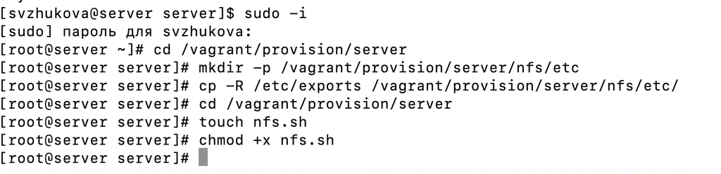

Создадим

## Открыв файл на редактирование, пропишем в нём следующий скрипт

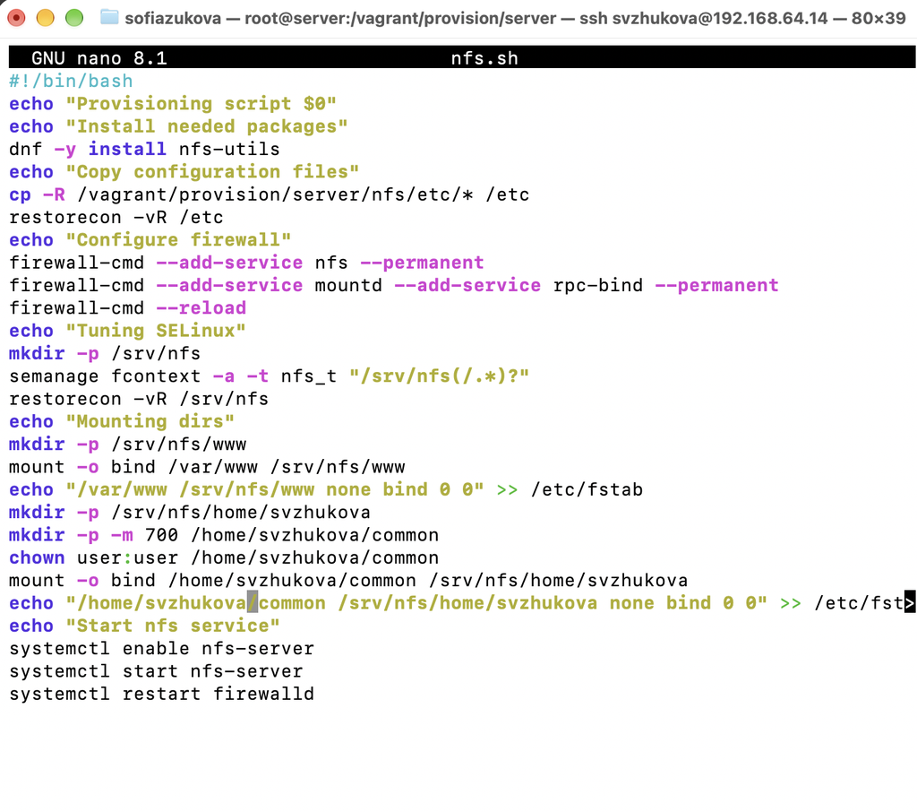

скрипт

## На виртуальной машине client перейдем в каталог для внесения изменений в настройки внутреннего окружения /vagrant/provision/client/, в каталоге /vagrant/provision/client создадим исполняемый файл nfs.sh и открыв его на редактирование, пропишем в нём следующий скрипт

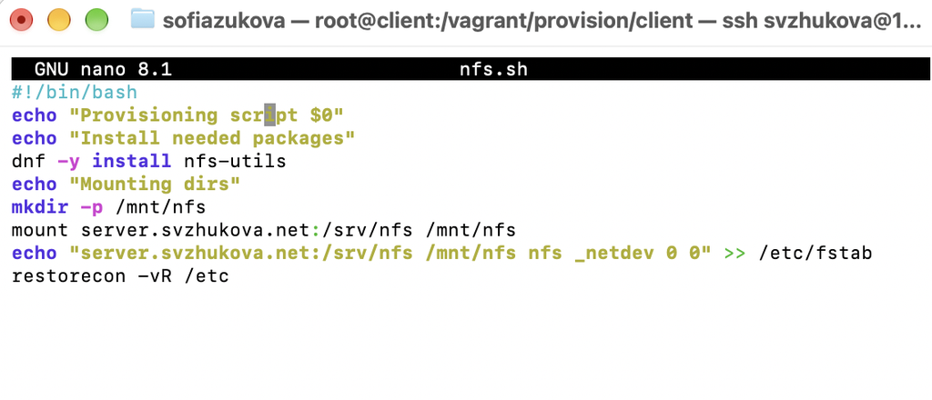

скрипт

## Для отработки созданных скриптов во время загрузки виртуальных машин server и client в конфигурационном файле Vagrantfile необходимо добавить в соответствующих разделах конфигураций для сервера и клиента

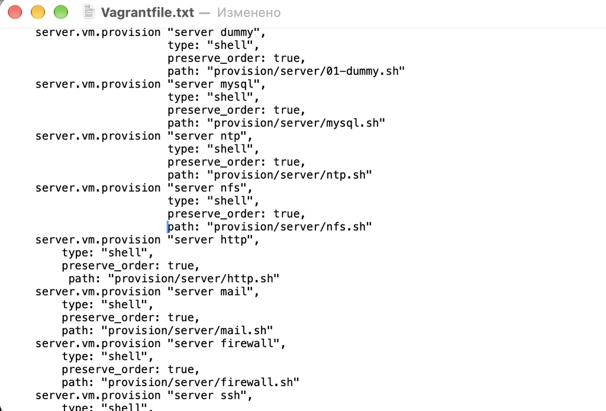

Vagrantfile

# Заключение

Мы приобрели навыки настройки сервера NFS для удалённого доступа к ресурсам.